# Getting Started with streamMetabolizer

Alison Appling

2016-07-08

## Introduction

This file demonstrates how to estimate stream metabolism using `streamMetabolizer` and some example data supplied by Bob Hall for French Creek in Laramie, WY.

## Setup

### Install

The most stable+current version of this package can be installed with this R command:

```r
install.packages("streamMetabolizer", dependencies=TRUE,
  repos=c("http://owi.usgs.gov/R","https://cran.rstudio.com"))
```

and updated with this command:

```r
update.packages(oldPkgs=c("streamMetabolizer","unitted"),
  dependencies=TRUE, repos=c("http://owi.usgs.gov/R", "https://cran.rstudio.com"))
```

The in-development version of the package can be installed with the `devtools` package. We can make no guarantees about the stability of this version, but it might have new features that you’ll like. If you go this route, you will need to install the package dependencies separately, like this:

```r
install.packages(
  c("LakeMetabolizer","unitted","dplyr","lazyeval","lubridate","magrittr",
    "tidyr","chron","dygraphs","ggplot2","RCurl","runjags","rstan","XML","xts"),
  repos=c("http://owi.usgs.gov/R","https://cran.rstudio.com"))
```

You can then install the most cutting edge version of streamMetabolizer with this command:

```r
devtools::install_github("USGS-R/streamMetabolizer", ref="develop")
```

Regardless of your installation method, if you plan to use Bayesian models with `engine='jags'`, you will also need to install [JAGS](http://mcmc-jags.sourceforge.net/).

### Load

Load the R libraries that will be used.

```r
suppressPackageStartupMessages({
  library(dplyr)
  library(tibble)
  library(tidyr)
  library(ggplot2)
  library(streamMetabolizer)
})
```

Load a moderately-sized example dataset from the package (data are from French Creek in Laramie, WY, courtesy of Bob Hall). Explicitly attached units are optional but useful for confirming that the data are in the expected format. We’ll use the `streamMetabolizer` standard in defining our day to run from 4 am (`day_start=4`) to 4 am (`day_end=28`).

```r
dat <- data_metab(num_days='3', res='15', day_start=4, day_end=28, attach.units=TRUE)
```

First inspect the dimensions, column names, and units of the data. Note that `unitted` data, such as that returned by `data_metab(..., attach.units=TRUE)`, prints out with a second row called ‘U’ giving the units for each column.

```r
dim(dat)
```

```
## [1] 288   6
```

```r
dat[c(1,48,96,240,288),] # some example rows
```

```
##              solar.time    DO.obs    DO.sat depth temp.water          light
## U                       mgO2 L^-1 mgO2 L^-1     m       degC umol m^-2 s^-1
## 2   2012-09-18 04:05:58      8.41  9.083329  0.16       3.60         0.0000
## 143 2012-09-18 15:50:58      8.36  7.403370  0.16      11.80       925.1370
## 287 2012-09-19 03:50:58      8.17  8.927566  0.16       4.25         0.0000
## 719 2012-09-20 15:50:58      8.35  7.358846  0.16      12.06       898.9231
## 863 2012-09-21 03:50:58      8.21  8.854844  0.16       4.56         0.0000
```

### Explore the input data

Now graphically inspect the input data.

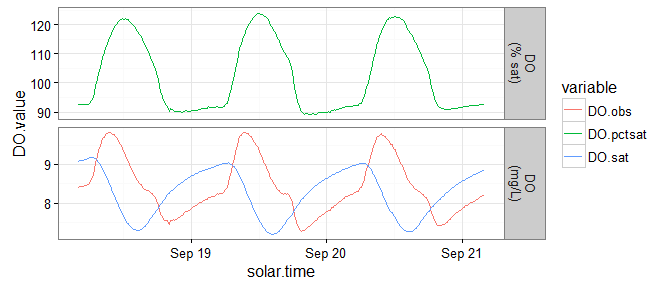

```r
dat %>% unitted::v() %>%
  mutate(DO.pctsat = 100 * (DO.obs / DO.sat)) %>%
  select(solar.time, starts_with('DO')) %>%
  gather(type, DO.value, starts_with('DO')) %>%
  mutate(units=ifelse(type == 'DO.pctsat', 'DO\n(% sat)', 'DO\n(mg/L)')) %>%
  ggplot(aes(x=solar.time, y=DO.value, color=type)) + geom_line() +
  facet_grid(units ~ ., scale='free_y') + theme_bw() +
  scale_color_discrete('variable')
```

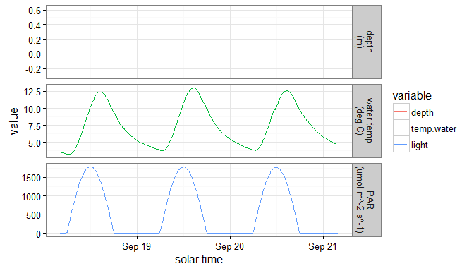

```r
labels <- c(depth='depth\n(m)', temp.water='water temp\n(deg C)', light='PAR\n(umol m^-2 s^-1)')
dat %>% unitted::v() %>%
  select(solar.time, depth, temp.water, light) %>%
  gather(type, value, depth, temp.water, light) %>%
  mutate(
    type=ordered(type, levels=c('depth','temp.water','light')),
    units=ordered(labels[type], unname(labels))) %>%
  ggplot(aes(x=solar.time, y=value, color=type)) + geom_line() +
  facet_grid(units ~ ., scale='free_y') + theme_bw() +
  scale_color_discrete('variable')
```

### Check the input data format

Our data need to have specific column names and units to fit an MLE, Bayesian, or nighttime-regression model. To see what is required, use the `metab_inputs` function to get a description of the required inputs for a given model type. The output of metab_inputs is a table describing the required column names, the classes and units of the values in each column, and whether that column is required or optional. The inputs are identical for the model types ‘mle’, ‘bayes’, and ‘night’, so here we’ll just print the requriements for ‘mle’.

```r
metab_inputs('mle', 'data')
```

```
##      colname          class          units     need
## 1 solar.time POSIXct,POSIXt                required
## 2     DO.obs        numeric      mgO2 L^-1 required
## 3     DO.sat        numeric      mgO2 L^-1 required
## 4      depth        numeric              m required
## 5 temp.water        numeric           degC required
## 6      light        numeric umol m^-2 s^-1 required
```

Our data format matches that of the requirements from `metab_inputs`:

```r
data.frame(
  colname=names(dat),
  class=unname(sapply(unitted::v(dat), function(col) paste(class(col), collapse=','))),
  units=unname(unitted::get_units(dat)))
```

```
##      colname          class          units
## 1 solar.time POSIXct,POSIXt
## 2     DO.obs        numeric      mgO2 L^-1
## 3     DO.sat        numeric      mgO2 L^-1
## 4      depth        numeric              m
## 5 temp.water        numeric           degC
## 6      light        numeric umol m^-2 s^-1
```

We’re ready to go.

## Modeling Overview

There are three steps to fitting a metabolism model in `streamMetabolizer`.

1. Identify the name of the model structure you want using `mm_name()`.
2. Set the specifications for the model using defaults from`specs()` as a starting point.
3. Fit the model with `metab()`.

## A Maximum Likelihood Model

### 1. Choose a model structure

A model is fully specified by a concise if cryptic model name. Examples are “b_np_oipi_pm_plrckm.stan” and “m_np_oi_pm_plrckm.nlm”. You never need to remember these concise names; instead, you can construct and interpret such names using the `mm_name` and `mm_parse_name` functions, respectively.

`streamMetabolizer` offers three core modeling `type`s: maximum likelihood estimation (‘mle’), hierarchical or non-hierarchical Bayesian models (‘bayes’), or nighttime regression (‘night’). It is always helpful in `mm_name` to specify the model `type` you want. Further structural details can be specified in `mm_name` or left to the defaults.

Here are some example calls to create and parse model names:

```r
three_names <- c(
  mm_name(type='mle'), # the default MLE model
  mm_name(type='mle', ode_method='Euler'), # override the default ode_method
  mm_name(type='bayes')) # the default Bayesian model
three_names
```

```
## [1] "m_np_oi_pm_plrckm.nlm"    "m_np_oi_eu_plrckm.nlm"    "b_np_oipi_pm_plrckm.stan"
```

```r
# parse the above model names
mm_parse_name(three_names)
```

```
##    type pool_K600 err_obs_iid err_proc_acor err_proc_iid ode_method  GPP_fun   ER_fun deficit_src
## 1   mle      none        TRUE         FALSE        FALSE  pairmeans linlight constant      DO_mod
## 2   mle      none        TRUE         FALSE        FALSE      Euler linlight constant      DO_mod
## 3 bayes      none        TRUE         FALSE         TRUE  pairmeans linlight constant      DO_mod
##   engine
## 1    nlm
## 2    nlm
## 3   stan
```

See the help file at `?mm_name` for a description of the arguments to `mm_name` and results from `mm_parse_name`.

Here we will fit the default MLE model. Many others are available (see Other Models below), but this one is common and fast. Call `mm_name` again to set the default MLE model name/structure.

```r
mle_name <- mm_name(type='mle')
mle_name
```

```
## [1] "m_np_oi_pm_plrckm.nlm"
```

### 2. Set the specifications

Having chosen a model, we next need to define a list of specifications for that model. The `specs` function creates a list appropriate to the model we chose.

```r
mle_specs <- specs(mle_name)
mle_specs
```

```
## Model specifications:
##   model_name  m_np_oi_pm_plrckm.nlm
##   day_start   4
##   day_end     28
##   day_tests   full_day, even_timesteps, complete_data
##   calc_DO_fun function; see element [['calc_DO_fun']] for details
##   ODE_method  pairmeans
##   GPP_init    10
##   ER_init     -10
##   K600_init   10
```

See `?specs` for definitions of all specifications. Note that most of the specifications in that help file are omitted from the output of `specs(mle_name)` above - this is because MLE models are simple and don’t have many parameters to set. Any of those parameters that are included in `model_specs` can be modified, either by calling `specs()` again or by replacing that value in the `model_specs` list. Here is a command that sets the the inital values of GPP, ER, and K600 for the likelihood maximization. (I’ve done this just for illustration; the model results aren’t affected by these particular changes for this particular dataset.)

```r
mle_specs <- specs(mle_name, GPP_init=2, ER_init=-1, K600_init=3)
```

### 3. Fit the model

Now actually fit the model using the `metab` function.

```r
mle_fit <- metab(mle_specs, data=dat, info=c(site='French Creek, WY', source='Bob Hall'))
```

It’s optional, but sometimes helpful, to include some sort of metadata in the `info`, as I’ve done above. I’ve chosen to put the metadata in a character vector, but metadata can take any format you like.

## Inspect the output

The `info` and `data` are saved in the fitted model object so we can reference them later.

```r
get_info(mle_fit)
```

```
##               site             source
## "French Creek, WY"         "Bob Hall"
```

```r
head(get_data(mle_fit))
```

```
##         date          solar.time DO.obs   DO.sat depth temp.water light   DO.mod
## 1 2012-09-18 2012-09-18 04:05:58   8.41 9.083329  0.16       3.60     0 8.410000
## 2 2012-09-18 2012-09-18 04:20:58   8.42 9.093063  0.16       3.56     0 8.421000
## 3 2012-09-18 2012-09-18 04:35:58   8.42 9.105254  0.16       3.51     0 8.431825
## 4 2012-09-18 2012-09-18 04:50:58   8.43 9.112582  0.16       3.48     0 8.442289
## 5 2012-09-18 2012-09-18 05:05:58   8.45 9.127267  0.16       3.42     0 8.452695
## 6 2012-09-18 2012-09-18 05:20:58   8.46 9.137079  0.16       3.38     0 8.463280
```

We can also get information about the model fitting process.

```r
get_fitting_time(mle_fit) # the time it took to fit the model
```

```
##    user  system elapsed
##    0.85    0.00    1.15
```

```r
get_version(mle_fit) # the streamMetabolizer version used to fit the model
```

```
## [1] "0.9.7.1"
```

```r
get_specs(mle_fit) # the specifications we passed in
```

```
## Model specifications:
##   model_name  m_np_oi_pm_plrckm.nlm
##   day_start   4
##   day_end     28
##   day_tests   full_day, even_timesteps, complete_data
##   calc_DO_fun function; see element [['calc_DO_fun']] for details
##   ODE_method  pairmeans
##   GPP_init    2
##   ER_init     -1
##   K600_init   3
```

There is a function to plot the daily metabolism estimates.

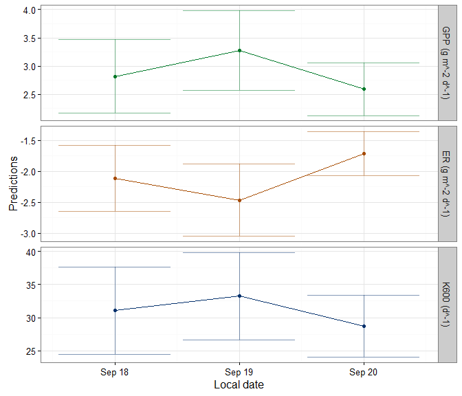

```r
plot_metab_preds(predict_metab(mle_fit))
```

There is also a function to plot the dissolved oxygen predictions (lines) along with the original observations (points).

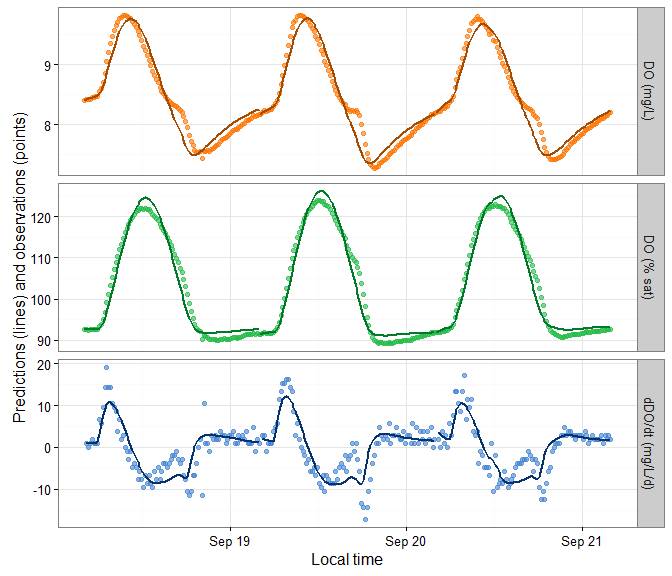

```r
plot_DO_preds(predict_DO(mle_fit))
```

## Other Models

Many model structures are available. We have only demonstrated one above (the default MLE model). Here is the full list of model options:

```r
all_models <- mm_valid_names(type=c('bayes','mle','night'))
opts <-
  bind_cols(
    tibble::tibble(model_name=all_models),
    mm_parse_name(all_models)) %>%
  arrange(model_name)
knitr::kable(opts)
```

| model_name | type | pool_K600 | err_obs_iid | err_proc_acor | err_proc_iid | ode_method | GPP_fun | ER_fun | deficit_src | engine |
| --- | --- | --- | --- | --- | --- | --- | --- | --- | --- | --- |
| b_Kb_oi_eu_plrckm.jags | bayes | binned | TRUE | FALSE | FALSE | Euler | linlight | constant | DO_mod | jags |
| b_Kb_oi_eu_plrckm.stan | bayes | binned | TRUE | FALSE | FALSE | Euler | linlight | constant | DO_mod | stan |
| b_Kb_oi_eu_plrcko.jags | bayes | binned | TRUE | FALSE | FALSE | Euler | linlight | constant | DO_obs | jags |
| b_Kb_oi_eu_plrcko.stan | bayes | binned | TRUE | FALSE | FALSE | Euler | linlight | constant | DO_obs | stan |
| b_Kb_oi_pm_plrckm.jags | bayes | binned | TRUE | FALSE | FALSE | pairmeans | linlight | constant | DO_mod | jags |
| b_Kb_oi_pm_plrckm.stan | bayes | binned | TRUE | FALSE | FALSE | pairmeans | linlight | constant | DO_mod | stan |
| b_Kb_oi_pm_plrcko.jags | bayes | binned | TRUE | FALSE | FALSE | pairmeans | linlight | constant | DO_obs | jags |
| b_Kb_oi_pm_plrcko.stan | bayes | binned | TRUE | FALSE | FALSE | pairmeans | linlight | constant | DO_obs | stan |
| b_Kb_oipc_eu_plrckm.jags | bayes | binned | TRUE | TRUE | FALSE | Euler | linlight | constant | DO_mod | jags |
| b_Kb_oipc_eu_plrckm.stan | bayes | binned | TRUE | TRUE | FALSE | Euler | linlight | constant | DO_mod | stan |
| b_Kb_oipc_eu_plrcko.jags | bayes | binned | TRUE | TRUE | FALSE | Euler | linlight | constant | DO_obs | jags |
| b_Kb_oipc_eu_plrcko.stan | bayes | binned | TRUE | TRUE | FALSE | Euler | linlight | constant | DO_obs | stan |
| b_Kb_oipc_pm_plrckm.jags | bayes | binned | TRUE | TRUE | FALSE | pairmeans | linlight | constant | DO_mod | jags |
| b_Kb_oipc_pm_plrckm.stan | bayes | binned | TRUE | TRUE | FALSE | pairmeans | linlight | constant | DO_mod | stan |
| b_Kb_oipc_pm_plrcko.jags | bayes | binned | TRUE | TRUE | FALSE | pairmeans | linlight | constant | DO_obs | jags |
| b_Kb_oipc_pm_plrcko.stan | bayes | binned | TRUE | TRUE | FALSE | pairmeans | linlight | constant | DO_obs | stan |
| b_Kb_oipcpi_eu_plrckm.jags | bayes | binned | TRUE | TRUE | TRUE | Euler | linlight | constant | DO_mod | jags |
| b_Kb_oipcpi_eu_plrckm.stan | bayes | binned | TRUE | TRUE | TRUE | Euler | linlight | constant | DO_mod | stan |
| b_Kb_oipcpi_eu_plrcko.jags | bayes | binned | TRUE | TRUE | TRUE | Euler | linlight | constant | DO_obs | jags |
| b_Kb_oipcpi_eu_plrcko.stan | bayes | binned | TRUE | TRUE | TRUE | Euler | linlight | constant | DO_obs | stan |
| b_Kb_oipcpi_pm_plrckm.jags | bayes | binned | TRUE | TRUE | TRUE | pairmeans | linlight | constant | DO_mod | jags |
| b_Kb_oipcpi_pm_plrckm.stan | bayes | binned | TRUE | TRUE | TRUE | pairmeans | linlight | constant | DO_mod | stan |
| b_Kb_oipcpi_pm_plrcko.jags | bayes | binned | TRUE | TRUE | TRUE | pairmeans | linlight | constant | DO_obs | jags |
| b_Kb_oipcpi_pm_plrcko.stan | bayes | binned | TRUE | TRUE | TRUE | pairmeans | linlight | constant | DO_obs | stan |
| b_Kb_oipi_eu_plrckm.jags | bayes | binned | TRUE | FALSE | TRUE | Euler | linlight | constant | DO_mod | jags |
| b_Kb_oipi_eu_plrckm.stan | bayes | binned | TRUE | FALSE | TRUE | Euler | linlight | constant | DO_mod | stan |
| b_Kb_oipi_eu_plrcko.jags | bayes | binned | TRUE | FALSE | TRUE | Euler | linlight | constant | DO_obs | jags |
| b_Kb_oipi_eu_plrcko.stan | bayes | binned | TRUE | FALSE | TRUE | Euler | linlight | constant | DO_obs | stan |
| b_Kb_oipi_pm_plrckm.jags | bayes | binned | TRUE | FALSE | TRUE | pairmeans | linlight | constant | DO_mod | jags |
| b_Kb_oipi_pm_plrckm.stan | bayes | binned | TRUE | FALSE | TRUE | pairmeans | linlight | constant | DO_mod | stan |

[output cut: 174 more lines]

Remember that any of these structures can be specified by using the model name directly or passing the corresponding arguments to `mm_name` to create the name.

## A Bayesian Model

### 1. Choose a model structure

For our second modeling example, we will specify everything about the model structure in our call to `mm_name`. (Some of these arguments are equal to the defaults and don’t technically need to be specified, but I want to show you that the available arguments are the same as those returned in the columns of the above table.)

```r
bayes_name <- mm_name(
  type='bayes', pool_K600='none',
  err_obs_iid=TRUE, err_proc_acor=FALSE, err_proc_iid=TRUE,
  ode_method='pairmeans', deficit_src='DO_mod', engine='stan')
bayes_name
```

```
## [1] "b_np_oipi_pm_plrckm.stan"
```

### 2. Set the specifications

Just as for the previous model, we now pass the model name to `specs()` to get a list of default specifications for this model. Note that the length and contents of this new specifications list differs substantially from the list we had for the MLE model.

```r
bayes_specs <- specs(bayes_name)
bayes_specs
```

```
## Model specifications:
##   model_name                  b_np_oipi_pm_plrckm.stan
##   engine                      stan
##   split_dates                 FALSE
##   keep_mcmcs                  TRUE
##   keep_mcmc_data              FALSE
##   day_start                   4
##   day_end                     28
##   day_tests                   full_day, even_timesteps, complete_data
##   GPP_daily_mu                10
##   GPP_daily_sigma             10
##   ER_daily_mu                 -10
##   ER_daily_sigma              10
##   K600_daily_mu               10
##   K600_daily_sigma            10
##   err_obs_iid_sigma_location  0
##   err_obs_iid_sigma_scale     3
##   err_proc_iid_sigma_location 0
##   err_proc_iid_sigma_scale    4
##   priors                      FALSE
##   params_out                  GPP_daily, ER_daily, K600_daily, err_obs_iid_sigma, err_proc_iid, e...
##   n_chains                    4
##   n_cores                     4
##   burnin_steps                500
##   saved_steps                 500
##   thin_steps                  1
##   verbose                     FALSE
```

At this point we can alter some of the specifications if desired.

```r
# one way to alter specifications: call specs() again
bayes_specs <- specs(bayes_name, burnin_steps=100, saved_steps=200, GPP_daily_mu=3, GPP_daily_sigma=2)
# another way: use replace()
bayes_specs <- replace(bayes_specs, 'split_dates', FALSE)
```

### 3. Fit the model

We now fit the model with the new specifications. Bayesian models take longer to run, so be patient.

```r
bayes_fit <- metab(bayes_specs, data=dat)
```

### 4. Explore as before

All of the same inspection functions are available as before, including `get_fitting_time`, `get_info`, `predict_metab`, and so on.

```r
get_fitting_time(bayes_fit)
```

```
##    user  system elapsed
##    1.31    0.48    8.52
```

```r
preds <- predict_metab(bayes_fit)
```

One slight difference is that hierarchical Bayesian models store their warnings and errors in attributes to the result of `predict_metab`. If there were any, you could inspect them like this:

```r
attr(preds, 'warnings')
```

```
## character(0)
```

```r
attr(preds, 'errors')
```

```
## character(0)
```

Here are the predictions from this last model:

```r
preds %>%
  lapply(function(col) if(is.numeric(col)) round(col, 2) else col ) %>%
  as.data.frame() %>%
  knitr::kable()
```

| date | GPP | GPP.lower | GPP.upper | ER | ER.lower | ER.upper | K600 | K600.lower | K600.upper | warnings | errors |
| --- | --- | --- | --- | --- | --- | --- | --- | --- | --- | --- | --- |
| 2012-09-18 | 3.11 | 0.88 | 5.75 | -2.32 | -6.55 | 1.76 | 36.80 | 20.70 | 54.22 | NA | NA |
| 2012-09-19 | 3.36 | 0.84 | 5.97 | -2.65 | -6.54 | 1.04 | 35.49 | 20.68 | 53.72 | NA | NA |
| 2012-09-20 | 3.40 | 1.08 | 5.81 | -2.50 | -6.22 | 0.61 | 36.33 | 19.68 | 53.01 | NA | NA |

You’re on your way!